# Untitled

### 데이터 불러오기

```r
library(Hmisc)
setwd("C:/Users/wjssm/Desktop/dy")
Q716=spss.get("HN16_ALL.sav",use.value.labels = TRUE)
Q717=spss.get("HN17_ALL.sav",use.value.labels = TRUE)
library(plyr)
Q7=rbind.fill(Q716,Q717)
```

### age

#### ~39 : 1

#### 40~59 : 2

#### 60~80 :3

```r
Q7=Q7[Q7$age>=19,]
Q7$age <- ifelse(Q7$age >= 60, 3,Q7$age)
Q7$age <- ifelse(Q7$age >=40, 2,Q7$age)
Q7$age <- ifelse(Q7$age >=19, 1,Q7$age)
```

### npins : 민간의료보험가입여부

```r
Q7$npins = with(Q7, ifelse(Q7$npins==2,0,npins))
Q7$npins = with(Q7, ifelse(Q7$npins==1,1,npins))
Q7$npins = with(Q7, ifelse(Q7$npins>=8,NA,npins))
```

### D.1.1 data : 주관적 건강상태(SRH)

```r
Q7$D.1.1 = with(Q7, ifelse(Q7$D.1.1<=3,1,D.1.1))
Q7$D.1.1 = with(Q7, ifelse(Q7$D.1.1>=8,NA,D.1.1))
Q7$D.1.1 = with(Q7, ifelse(Q7$D.1.1>=4,0,D.1.1))
Q7$SRH = Q7$D.1.1
```

### 질병 변수

```r
# DE1.pr : 당뇨병(DM)
Q7$DM = with(Q7, ifelse(DE1.pr == 9 , NA,
                        ifelse(DE1.pr ==8,0,DE1.pr)))
# DI1.pr : 고혈압(hypertension)
Q7$hypertension = with(Q7, ifelse(DI1.pr == 9 , NA,
                        ifelse(DI1.pr ==8,0,DI1.pr)))
# DC1.pr : 위암
Q7$stomach = with(Q7, ifelse(DC1.pr == 9 , NA,
                        ifelse(DC1.pr ==8,0,DC1.pr)))
# DC2.pr : 간암
Q7$liver = with(Q7, ifelse(DC2.pr == 9 , NA,
                        ifelse(DC2.pr ==8,0,DC2.pr)))
# DC3.pr : 대장암
Q7$colorectal = with(Q7, ifelse(DC3.pr == 9 , NA,
                        ifelse(DC3.pr ==8,0,DC3.pr)))
# DC4.pr : 유방암
Q7$breast = with(Q7, ifelse(DC4.pr == 9 , NA,
                        ifelse(DC4.pr ==8,0,DC4.pr)))
# DC5.pr : 자궁경부암
Q7$cervical = with(Q7, ifelse(DC5.pr == 9 , NA,
                        ifelse(DC5.pr ==8,0,DC5.pr)))
# DC6.pr : 갑상선암
Q7$thyroid = with(Q7, ifelse(DC6.pr == 9 , NA,
                        ifelse(DC6.pr ==8,0,DC6.pr)))
```

```r
library(dplyr)
Select = c("age","sex","SRH","npins", "DM","ho.incm",'edu','hypertension',
'stomach','liver','colorectal','breast','cervical','thyroid')
Dat = Q7 [,Select]
#na chek
sapply(Dat, function(x) sum(is.na(x)))
```

```
##          age          sex          SRH        npins           DM
##            0            0         1195          121          588
##      ho.incm          edu hypertension      stomach        liver
##           53         1278          586         1208         1208
##   colorectal       breast     cervical      thyroid
##         1208         1208         1208         1208
```

```r
#only complete case
Dat$ok = complete.cases(Dat)
Dat = Dat[Dat$ok==1,]
sum(!complete.cases(Dat))
```

```
## [1] 0
```

```r
head(Dat)
```

```
##   age sex SRH npins DM ho.incm edu hypertension stomach liver colorectal
## 1   3   1   1     1  1       3   4            1       0     0          0
## 2   2   2   1     1  0       3   4            0       0     0          0
## 3   2   2   1     1  0       3   4            0       0     0          0
## 4   1   1   0     1  0       3   4            0       0     0          0
## 5   1   2   1     1  0       3   4            0       0     0          0
## 8   2   2   1     1  0       4   4            0       0     0          0
##   breast cervical thyroid   ok
## 1      0        0       0 TRUE
## 2      0        0       0 TRUE
## 3      0        0       0 TRUE
## 4      0        0       0 TRUE
## 5      0        0       0 TRUE
## 8      0        0       0 TRUE
```

```r
library(MASS)
library(moonBook)
tab2=mytable(npins~.-ok, data=Dat)
tab2
```

```
##
##           Descriptive Statistics by 'npins'
## _____________________________________________________
##                            0            1         p
##                         (N=2702)     (N=8816)
## -----------------------------------------------------
##  age                                            0.000
##    - 1                328 (12.1%)  2898 (32.9%)
##    - 2                414 (15.3%)  3914 (44.4%)
##    - 3                1960 (72.5%) 2004 (22.7%)
##   성별                                            0.001
##    - 1                1251 (46.3%) 3756 (42.6%)
##    - 2                1451 (53.7%) 5060 (57.4%)
##  SRH                                            0.000
##    - 0                867 (32.1%)  1422 (16.1%)
##    - 1                1835 (67.9%) 7394 (83.9%)
##  DM                                             0.000
##    - 0                2181 (80.7%) 8242 (93.5%)
##    - 1                521 (19.3%)  574 ( 6.5%)
##     소득4분위수(가구)                                  0.000
##    - 1                1342 (49.7%) 882 (10.0%)
##    - 2                689 (25.5%)  2106 (23.9%)
##    - 3                398 (14.7%)  2765 (31.4%)
##    - 4                273 (10.1%)  3063 (34.7%)
##      교육수준 재분류 코드                                0.000
##    - 1                1336 (49.4%) 1129 (12.8%)
##    - 2                328 (12.1%)  845 ( 9.6%)
##    - 3                601 (22.2%)  2988 (33.9%)
##    - 4                437 (16.2%)  3854 (43.7%)
##  hypertension                                   0.000
##    - 0                1512 (56.0%) 7296 (82.8%)
##    - 1                1190 (44.0%) 1520 (17.2%)
##  stomach                                        0.000
##    - 0                2686 (99.4%) 8802 (99.8%)
##    - 1                 16 ( 0.6%)   14 ( 0.2%)
##  liver                                          0.069
##    - 0                2695 (99.7%) 8808 (99.9%)
##    - 1                 7 ( 0.3%)    8 ( 0.1%)
##  colorectal                                     0.302
##    - 0                2696 (99.8%) 8806 (99.9%)
##    - 1                 6 ( 0.2%)    10 ( 0.1%)
##  breast                                         0.356
##    - 0                2697 (99.8%) 8788 (99.7%)
##    - 1                 5 ( 0.2%)    28 ( 0.3%)
##  cervical                                       0.881
##    - 0                2699 (99.9%) 8803 (99.9%)
##    - 1                 3 ( 0.1%)    13 ( 0.1%)
##  thyroid                                        0.227
##    - 0                2696 (99.8%) 8807 (99.9%)
##    - 1                 6 ( 0.2%)    9 ( 0.1%)
## -----------------------------------------------------
```

# visualization

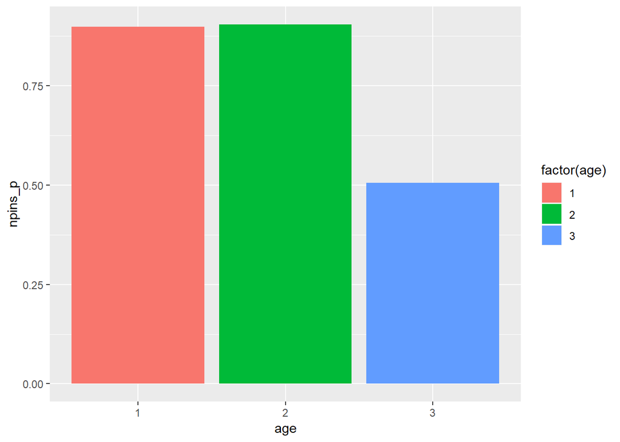

```r
library(ggplot2); library(dplyr)

Dat %>% group_by(age) %>% summarise(npins_p = mean(npins)) %>%
  ggplot()+geom_bar(aes(factor(age), npins_p,
                        fill = factor(age)), stat = 'identity')+
  xlab("age")
```

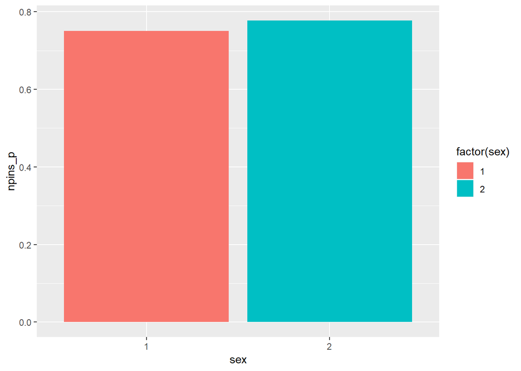

```r
Dat %>% group_by(sex) %>% summarise(npins_p = mean(npins)) %>%
  ggplot()+geom_bar(aes(factor(sex), npins_p,
                        fill = factor(sex)), stat = 'identity')+
  xlab("sex")
```

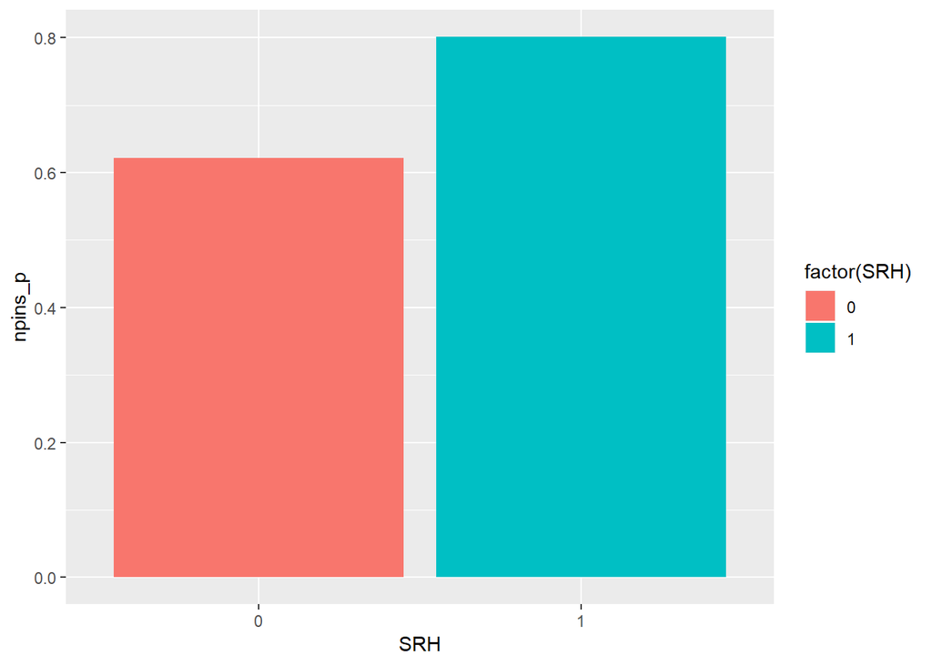

```r
Dat %>% group_by(SRH) %>% summarise(npins_p = mean(npins)) %>%
  ggplot()+geom_bar(aes(factor(SRH), npins_p,
                        fill = factor(SRH)), stat = 'identity')+
  xlab("SRH")
```

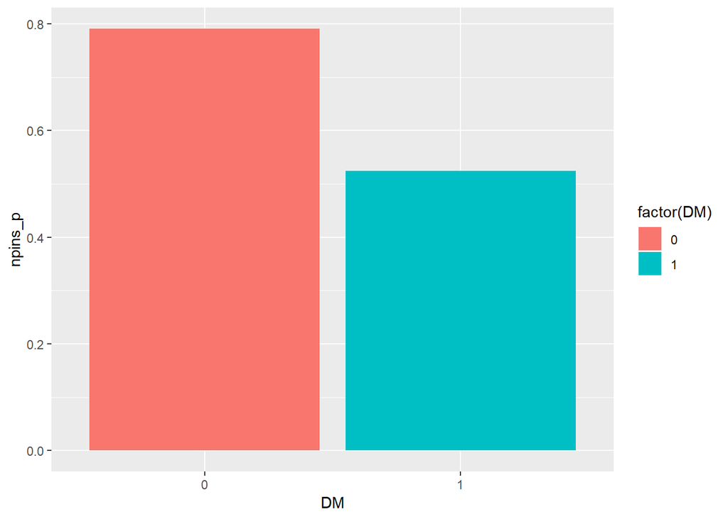

```r
Dat %>% group_by(DM) %>% summarise(npins_p = mean(npins)) %>%
  ggplot()+geom_bar(aes(factor(DM), npins_p,
                        fill = factor(DM)), stat = 'identity')+
  xlab("DM")
```

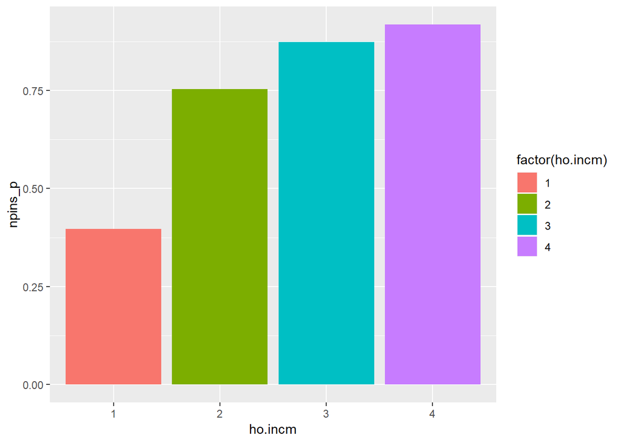

```r
Dat %>% group_by(ho.incm) %>% summarise(npins_p = mean(npins)) %>%
  ggplot()+geom_bar(aes(factor(ho.incm), npins_p,
                        fill = factor(ho.incm)), stat = 'identity')+
  xlab("ho.incm")
```

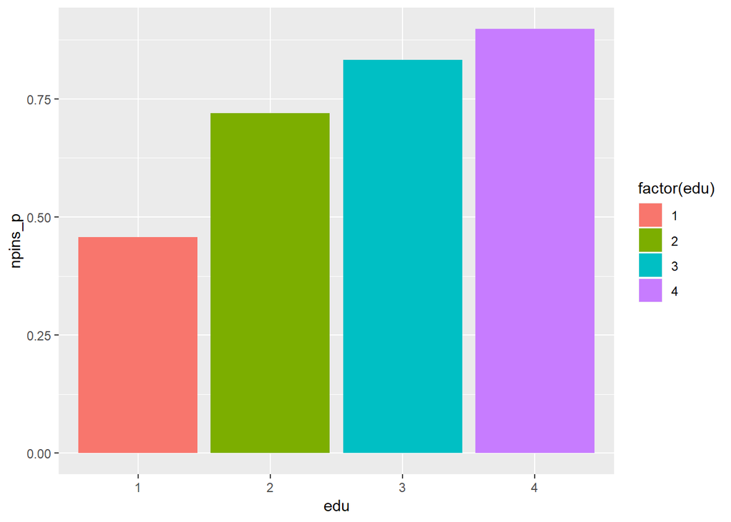

```r
Dat %>% group_by(edu) %>% summarise(npins_p = mean(npins)) %>%
  ggplot()+geom_bar(aes(factor(edu), npins_p,
                        fill = factor(edu)), stat = 'identity')+
  xlab("edu")
```

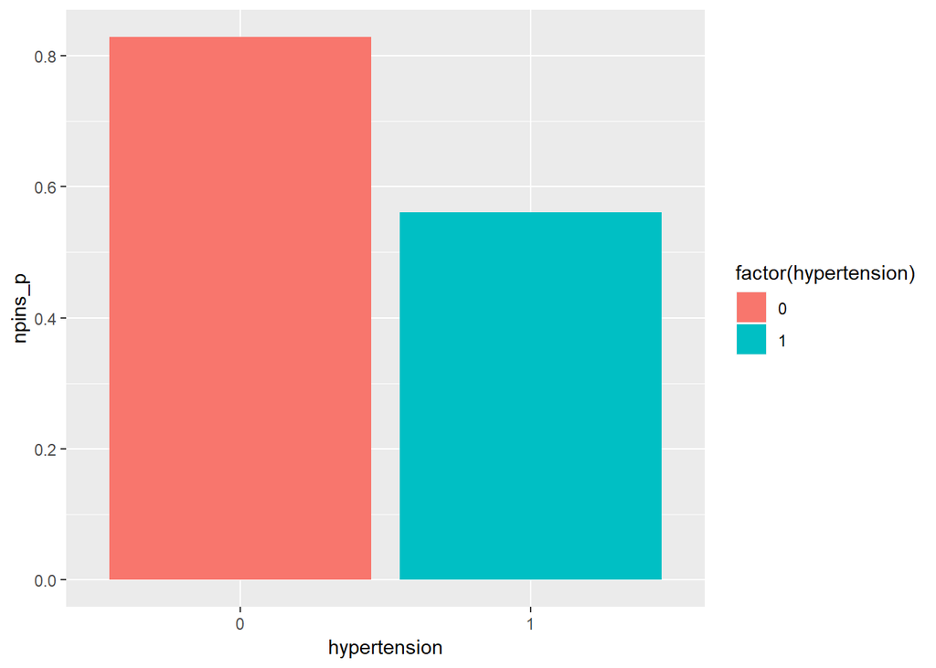

```r
Dat %>% group_by(hypertension) %>% summarise(npins_p = mean(npins)) %>% ggplot()+geom_bar(aes(factor(hypertension), npins_p,
                  fill = factor(hypertension)), stat = 'identity')+
  xlab("hypertension")
```

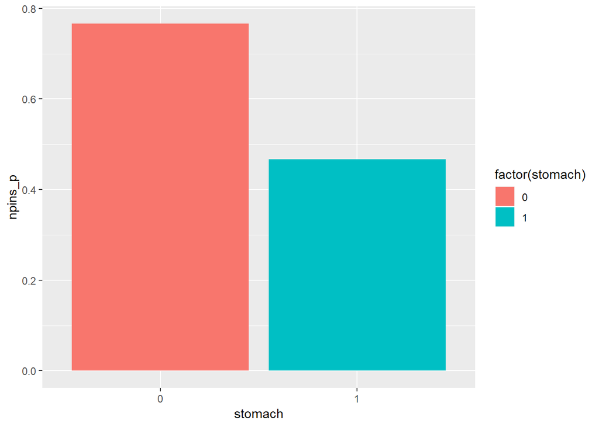

```r
Dat %>% group_by(stomach) %>% summarise(npins_p = mean(npins)) %>%
  ggplot()+geom_bar(aes(factor(stomach), npins_p,
                    fill = factor(stomach)), stat = 'identity')+
  xlab("stomach")
```

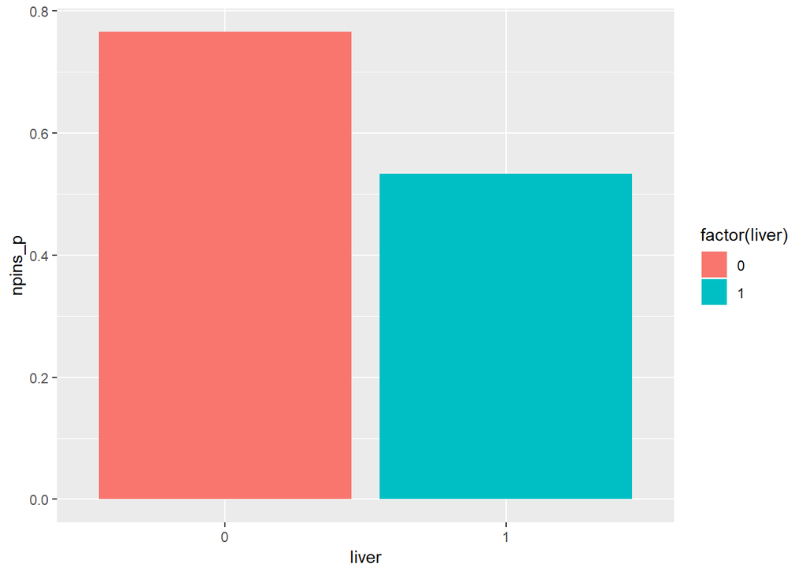

```r
Dat %>% group_by(liver) %>% summarise(npins_p = mean(npins)) %>%
  ggplot()+geom_bar(aes(factor(liver), npins_p,
                      fill = factor(liver)), stat = 'identity')+
  xlab("liver")
```

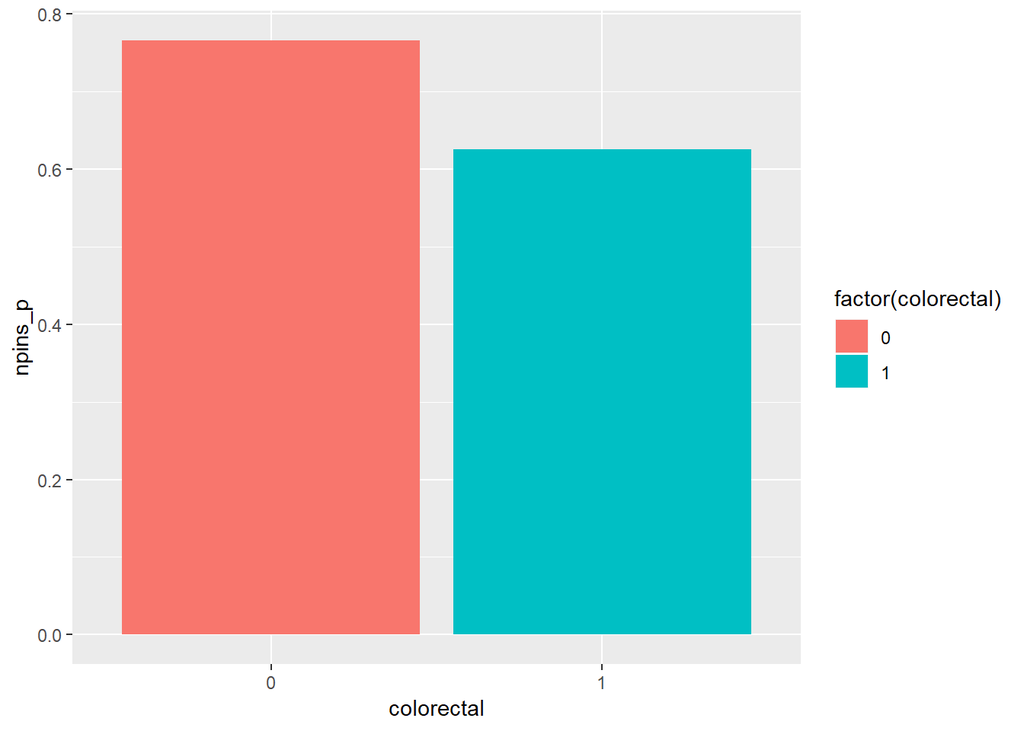

```r
Dat %>% group_by(colorectal) %>% summarise(npins_p = mean(npins)) %>%
  ggplot()+geom_bar(aes(factor(colorectal), npins_p,
                  fill = factor(colorectal)), stat = 'identity')+
  xlab("colorectal")
```

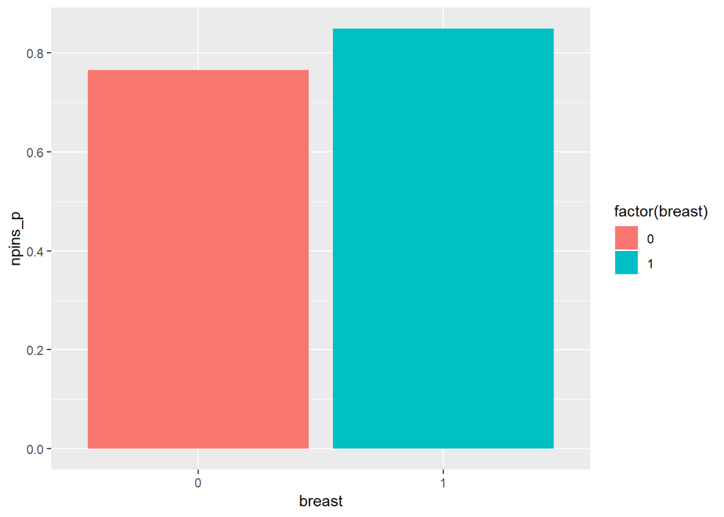

```r
Dat %>% group_by(breast) %>% summarise(npins_p = mean(npins)) %>%
  ggplot()+geom_bar(aes(factor(breast), npins_p,
                    fill = factor(breast)), stat = 'identity')+
  xlab("breast")
```

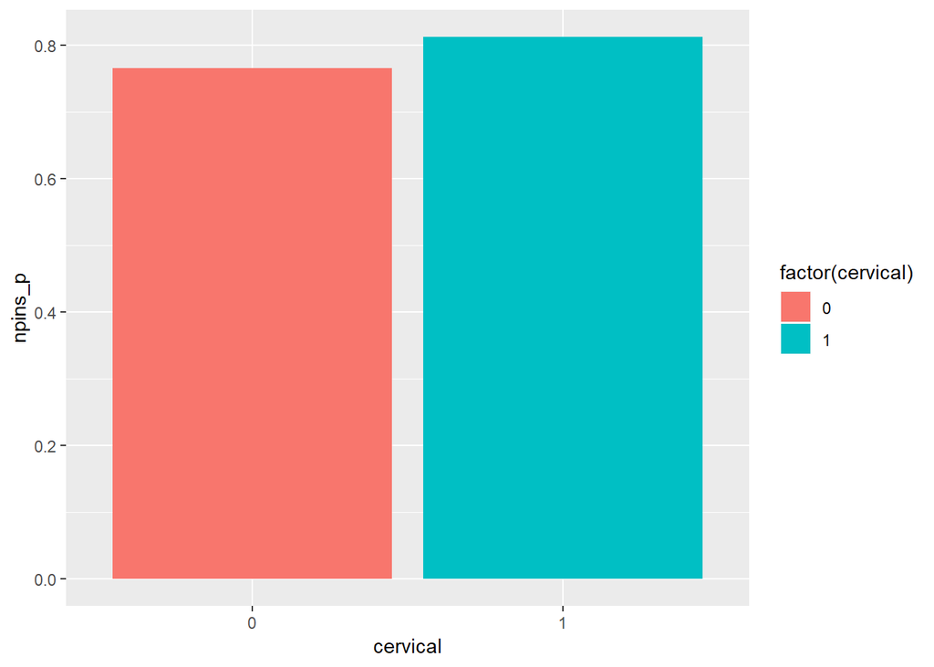

```r
Dat %>% group_by(cervical) %>% summarise(npins_p = mean(npins)) %>%
  ggplot()+geom_bar(aes(factor(cervical), npins_p,
                    fill = factor(cervical)), stat = 'identity')+
  xlab("cervical")
```

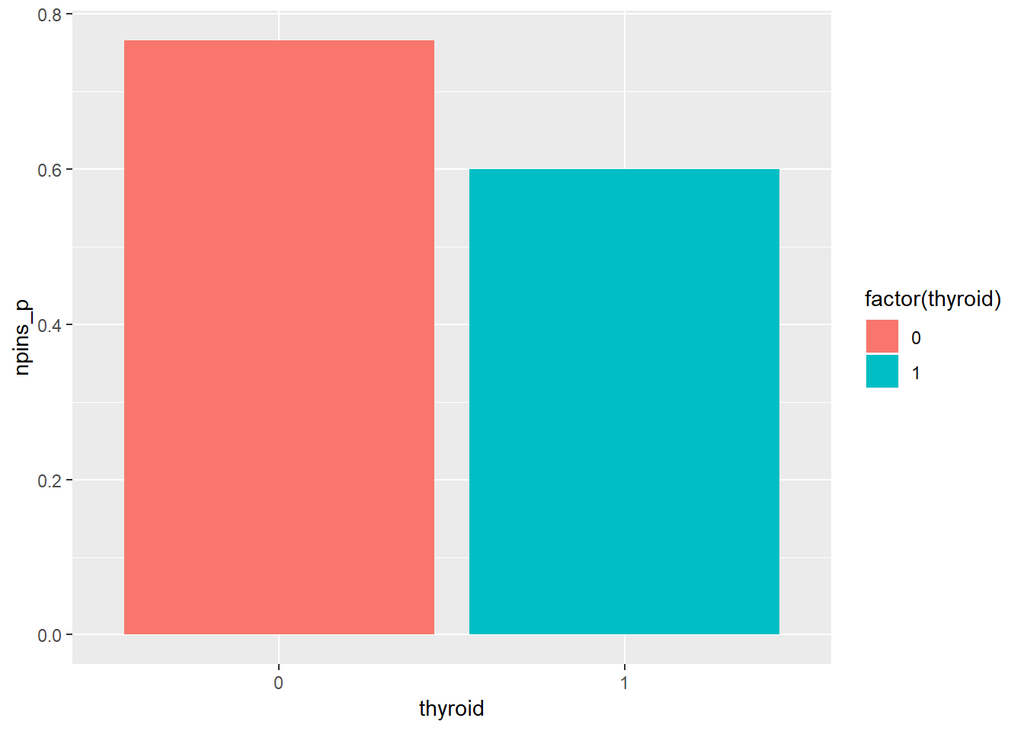

```r
Dat %>% group_by(thyroid) %>% summarise(npins_p = mean(npins)) %>%
  ggplot()+geom_bar(aes(factor(thyroid), npins_p,
                        fill = factor(thyroid)), stat = 'identity')+
  xlab("thyroid")
```

# modeling

### 1. npins ~ SRH

```r
m1 = glm(npins~SRH, family = binomial, data=Dat)
summary(m1) #SRH p-value <0.05 통계적으로 유의한 변수
```

```
##
## Call:
## glm(formula = npins ~ SRH, family = binomial, data = Dat)
##
## Deviance Residuals:
##     Min       1Q   Median       3Q      Max
## -1.7974   0.6659   0.6659   0.6659   0.9758
##
## Coefficients:
##             Estimate Std. Error z value Pr(>|z|)
## (Intercept)  0.49478    0.04309   11.48   <2e-16 ***
## SRH          0.89884    0.05037   17.85   <2e-16 ***
## ---
## Signif. codes:  0 '***' 0.001 '**' 0.01 '*' 0.05 '.' 0.1 ' ' 1
##
## (Dispersion parameter for binomial family taken to be 1)
##
##     Null deviance: 12549  on 11517  degrees of freedom
## Residual deviance: 12244  on 11516  degrees of freedom
## AIC: 12248
##
## Number of Fisher Scoring iterations: 4
```

```r
round(exp(cbind("odds ratio"=coef(m1), confint(m1))),2)
```

```
##             odds ratio 2.5 % 97.5 %
## (Intercept)       1.64  1.51   1.79
## SRH               2.46  2.23   2.71
```

odds ratio > 1 주관적 건강상태가 좋을수록 민간의료보험가입할 Odds가 높다.

### 2. 환자 info variables

```r
m3 = glm(npins ~ age+factor(sex)+edu+ho.incm+SRH, data = Dat, family = binomial)
summary(m3)
```

```
##
## Call:
## glm(formula = npins ~ age + factor(sex) + edu + ho.incm + SRH,
##     family = binomial, data = Dat)
##
## Deviance Residuals:
##     Min       1Q   Median       3Q      Max
## -2.8062   0.1985   0.3635   0.6048   1.7148
##
## Coefficients:
##              Estimate Std. Error z value Pr(>|z|)
## (Intercept)   0.22715    0.16820   1.350    0.177
## age          -0.79084    0.04326 -18.279  < 2e-16 ***
## factor(sex)2  0.44284    0.05327   8.314  < 2e-16 ***
## edu           0.24330    0.02821   8.624  < 2e-16 ***
## ho.incm       0.69303    0.02753  25.176  < 2e-16 ***
## SRH           0.29314    0.06007   4.880 1.06e-06 ***
## ---
## Signif. codes:  0 '***' 0.001 '**' 0.01 '*' 0.05 '.' 0.1 ' ' 1
##
## (Dispersion parameter for binomial family taken to be 1)
##
##     Null deviance: 12549.1  on 11517  degrees of freedom
## Residual deviance:  9545.7  on 11512  degrees of freedom
## AIC: 9557.7
##
## Number of Fisher Scoring iterations: 5
```

- 모두 통계적으로 유의미한 변수ㄷ
- age 의 계수만 음수 -> 나이가 어릴수록 민간의료보험가입.
- 여자일수록, 교육수준이 높을수록, 소득수준이 높을수록, 주관적 건강상태가 좋을수록 민간의료보험가입할 확률이 높다.

### 3. 환자 info + 질병변수들

```r
m4 <- glm(npins ~ age+factor(sex)+edu+ho.incm+SRH+
            DM+hypertension+stomach+liver+colorectal+breast+
          cervical+thyroid, data = Dat, family = binomial)
summary(m4)
```

```
##
## Call:
## glm(formula = npins ~ age + factor(sex) + edu + ho.incm + SRH +
##     DM + hypertension + stomach + liver + colorectal + breast +
##     cervical + thyroid, family = binomial, data = Dat)
##
## Deviance Residuals:
##     Min       1Q   Median       3Q      Max
## -2.7902   0.2030   0.3891   0.6119   1.8468
##
## Coefficients:
##               Estimate Std. Error z value Pr(>|z|)
## (Intercept)   0.255640   0.168829   1.514 0.129978
## age          -0.699004   0.045425 -15.388  < 2e-16 ***
## factor(sex)2  0.415674   0.053655   7.747 9.40e-15 ***
## edu           0.231697   0.028403   8.157 3.42e-16 ***
## ho.incm       0.686569   0.027618  24.860  < 2e-16 ***
## SRH           0.226610   0.061283   3.698 0.000218 ***
## DM           -0.280136   0.077351  -3.622 0.000293 ***
## hypertension -0.301567   0.059892  -5.035 4.77e-07 ***
## stomach      -0.643822   0.440660  -1.461 0.144004
## liver        -0.560108   0.571743  -0.980 0.327259
## colorectal   -0.136419   0.600457  -0.227 0.820275
## breast        0.372874   0.544892   0.684 0.493780
## cervical      0.343570   0.763497   0.450 0.652713
## thyroid       0.004356   0.586953   0.007 0.994078
## ---
## Signif. codes:  0 '***' 0.001 '**' 0.01 '*' 0.05 '.' 0.1 ' ' 1
##
## (Dispersion parameter for binomial family taken to be 1)
##
##     Null deviance: 12549.1  on 11517  degrees of freedom
## Residual deviance:  9495.2  on 11504  degrees of freedom
## AIC: 9523.2
##
## Number of Fisher Scoring iterations: 5
```

- 통계적으로 유의미하지않은 변수들도 보인다
- 따라서 step을 이용하여 변수선택.

```r
m4.final = step(m4)
```

```
## Start:  AIC=9523.16
## npins ~ age + factor(sex) + edu + ho.incm + SRH + DM + hypertension +
##     stomach + liver + colorectal + breast + cervical + thyroid
##
##                Df Deviance     AIC
## - thyroid       1   9495.2  9521.2
## - colorectal    1   9495.2  9521.2
## - cervical      1   9495.4  9521.4
## - breast        1   9495.7  9521.7
## - liver         1   9496.1  9522.1
## <none>              9495.2  9523.2
## - stomach       1   9497.3  9523.3
## - DM            1   9508.2  9534.2
## - SRH           1   9508.7  9534.7
## - hypertension  1   9520.3  9546.3
## - factor(sex)   1   9555.6  9581.6
## - edu           1   9561.7  9587.7
## - age           1   9740.6  9766.6
## - ho.incm       1  10165.8 10191.8
##
## Step:  AIC=9521.16
## npins ~ age + factor(sex) + edu + ho.incm + SRH + DM + hypertension +
##     stomach + liver + colorectal + breast + cervical
##
##                Df Deviance     AIC
## - colorectal    1   9495.2  9519.2
## - cervical      1   9495.4  9519.4
## - breast        1   9495.7  9519.7
## - liver         1   9496.1  9520.1
## <none>              9495.2  9521.2
## - stomach       1   9497.3  9521.3
## - DM            1   9508.2  9532.2
## - SRH           1   9508.7  9532.7
## - hypertension  1   9520.3  9544.3
## - factor(sex)   1   9555.7  9579.7
## - edu           1   9561.7  9585.7
## - age           1   9740.9  9764.9
## - ho.incm       1  10166.2 10190.2
##
## Step:  AIC=9519.21
```

[output cut: 49 more lines]

```
##
## Step:  AIC=9514.9
## npins ~ age + factor(sex) + edu + ho.incm + SRH + DM + hypertension +
##     stomach
##
##                Df Deviance     AIC
## <none>              9496.9  9514.9
## - stomach       1   9499.1  9515.1
## - DM            1   9510.0  9526.0
## - SRH           1   9510.9  9526.9
## - hypertension  1   9521.9  9537.9
## - factor(sex)   1   9558.8  9574.8
## - edu           1   9563.4  9579.4
## - age           1   9743.9  9759.9
## - ho.incm       1  10167.4 10183.4
```

```r
summary(m4.final)
```

```
##
## Call:
## glm(formula = npins ~ age + factor(sex) + edu + ho.incm + SRH +
##     DM + hypertension + stomach, family = binomial, data = Dat)
##
## Deviance Residuals:
##     Min       1Q   Median       3Q      Max
## -2.7912   0.2027   0.3897   0.6140   1.8484
##
## Coefficients:
##              Estimate Std. Error z value Pr(>|z|)
## (Intercept)   0.25600    0.16882   1.516 0.129425
## age          -0.70033    0.04537 -15.435  < 2e-16 ***
## factor(sex)2  0.41954    0.05354   7.836 4.64e-15 ***
## edu           0.23148    0.02839   8.154 3.51e-16 ***
## ho.incm       0.68602    0.02760  24.858  < 2e-16 ***
## SRH           0.22953    0.06109   3.758 0.000172 ***
## DM           -0.28029    0.07731  -3.625 0.000288 ***
## hypertension -0.30071    0.05987  -5.022 5.10e-07 ***
## stomach      -0.64242    0.44067  -1.458 0.144887
## ---
## Signif. codes:  0 '***' 0.001 '**' 0.01 '*' 0.05 '.' 0.1 ' ' 1
##
## (Dispersion parameter for binomial family taken to be 1)
##
##     Null deviance: 12549.1  on 11517  degrees of freedom
## Residual deviance:  9496.9  on 11509  degrees of freedom
## AIC: 9514.9
##
## Number of Fisher Scoring iterations: 5
```

### 4. controlling income

```r
income1 = glm(npins~SRH, subset =(ho.incm==1), family = binomial, data=Dat)
round(exp(cbind("odds ratio"=coef(income1), confint(income1))),2)
```

```
##             odds ratio 2.5 % 97.5 %
## (Intercept)       0.49  0.43   0.57
## SRH               1.56  1.30   1.87
```

```r
income2 = glm(npins~SRH, subset =(ho.incm==2), family = binomial, data=Dat)
round(exp(cbind("odds ratio"=coef(income2), confint(income2))),2)
```

```
##             odds ratio 2.5 % 97.5 %
## (Intercept)       2.12  1.78   2.54
## SRH               1.60  1.30   1.95
```

```r
income3 = glm(npins~SRH, subset =(ho.incm==3), family = binomial, data=Dat)
round(exp(cbind("odds ratio"=coef(income3), confint(income3))),2)
```

```
##             odds ratio 2.5 % 97.5 %
## (Intercept)       4.61  3.68   5.85
## SRH               1.65  1.27   2.13
```

```r
income4 = glm(npins~SRH, subset =(ho.incm==4), family = binomial, data=Dat)
round(exp(cbind("odds ratio"=coef(income4), confint(income4))),2)
```

```
##             odds ratio 2.5 % 97.5 %
## (Intercept)       8.07  5.99  11.14
## SRH               1.47  1.04   2.04
```

- 어떤 소득분위를 가지든 odds ratio가 1보다 크다.
- 소득분위에 따라 Odds ratio가 크게 달라지지 않는다.
- 소득분위의 관계없이 주관적 건강상태가 좋을수록 민간의료보험가입할 Odds가 높다.

### 5-1. ho.incm * SRH

```r
m2.1 = glm(npins~SRH + factor(ho.incm),family = binomial,data=Dat)

#교호작용 추가한 모델
m2.1.interaction = glm(npins~SRH*factor(ho.incm),family =binomial,data=Dat)

anova(m2.1, m2.1.interaction, test="LRT")
```

```
## Analysis of Deviance Table
##
## Model 1: npins ~ SRH + factor(ho.incm)
## Model 2: npins ~ SRH * factor(ho.incm)
##   Resid. Df Resid. Dev Df Deviance Pr(>Chi)
## 1     11513      10331
## 2     11510      10331  3  0.31753   0.9567
```

- m2.1 모델(SRH + factor(ho.incm))과 m2.1모델에 SRH, factor(ho.incm)의 교호작용을 추가한 모델을 anova로 비교.
- p-value 가 굉장히 큰 값.->accept H0
- 교호작용을 추가하지 않은 경우가 더 좋은 모델이라고 할 수 있다.

### 5-2. age * SRH

```r
m2.2 = glm(npins~SRH + factor(age),family = binomial,data=Dat)

#교호작용 추가한 모델
m2.2.interaction = glm(npins~SRH*factor(age),family =binomial,data=Dat)

anova(m2.2, m2.2.interaction, test="LRT")
```

```
## Analysis of Deviance Table
##
## Model 1: npins ~ SRH + factor(age)
## Model 2: npins ~ SRH * factor(age)
##   Resid. Df Resid. Dev Df Deviance Pr(>Chi)
## 1     11514      10250
## 2     11512      10238  2   12.094 0.002366 **
## ---
## Signif. codes:  0 '***' 0.001 '**' 0.01 '*' 0.05 '.' 0.1 ' ' 1
```

- m2.2 모델(SRH + factor(age))과 m2.1모델에 SRH, factor(age)의 교호작용을 추가한 모델을 anova로 비교.
- p-value < 0.05 .-> reject H0
- 교호작용을 추가한 경우가 더 좋은 모델이라고 할 수 있다.

### 5-3. sex * SRH

```r
m2.3 = glm(npins~SRH + factor(sex),family = binomial,data=Dat)

#교호작용 추가한 모델
m2.3.interaction = glm(npins~SRH*factor(sex),family =binomial,data=Dat)

anova(m2.3, m2.3.interaction, test="LRT")
```

```
## Analysis of Deviance Table
##
## Model 1: npins ~ SRH + factor(sex)
## Model 2: npins ~ SRH * factor(sex)
##   Resid. Df Resid. Dev Df Deviance Pr(>Chi)
## 1     11515      12220
## 2     11514      12218  1   2.4299    0.119
```

- m2.3 모델(SRH + factor(sex))과 SRH, factor(sex)의 교호작용을 추가한 모델을 anova로 비교.
- p-value > 0.05.->accept H0
- 교호작용을 추가하지 않은 경우가 더 좋은 모델이라고 할 수 있다.

### 5-4. edu * SRH

```r
m2.4 = glm(npins~SRH + factor(edu),family = binomial,data=Dat)

#교호작용 추가한 모델
m2.4.interaction = glm(npins~SRH*factor(edu),family =binomial,data=Dat)

anova(m2.4, m2.4.interaction, test="LRT")
```

```
## Analysis of Deviance Table
##
## Model 1: npins ~ SRH + factor(edu)
## Model 2: npins ~ SRH * factor(edu)
##   Resid. Df Resid. Dev Df Deviance Pr(>Chi)
## 1     11513      10788
## 2     11510      10786  3   1.5437   0.6722
```

- m2.4 모델(SRH + factor(edu))과 m2.4모델에 SRH, factor(edu)의 교호작용을 추가한 모델을 anova로 비교.
- p-value > 0.05 값.->accept H0
- 교호작용을 추가하지 않은 경우가 더 좋은 모델이라고 할 수 있다.

```r
m2.5 = glm(npins~SRH + factor(DM),family = binomial,data=Dat)

#교호작용 추가한 모델
m2.5.interaction = glm(npins~SRH*factor(DM),family =binomial,data=Dat)

anova(m2.5, m2.5.interaction, test="LRT")
```

```
## Analysis of Deviance Table
##
## Model 1: npins ~ SRH + factor(DM)
## Model 2: npins ~ SRH * factor(DM)
##   Resid. Df Resid. Dev Df Deviance  Pr(>Chi)
## 1     11515      11999
## 2     11514      11986  1   12.921 0.0003249 ***
## ---
## Signif. codes:  0 '***' 0.001 '**' 0.01 '*' 0.05 '.' 0.1 ' ' 1
```

- m2.5 모델(SRH + factor(DM))과 m2.5모델에 SRH, factor(DM)의 교호작용을 추가한 모델을 anova로 비교.
- p-value < 0.05 .-> reject H0
- 교호작용을 추가한 경우가 더 좋은 모델이라고 할 수 있다.

### 5-6. hypertension * SRH

```r
m2.6 = glm(npins~SRH + factor(hypertension),family = binomial,data=Dat)

#교호작용 추가한 모델
m2.6.interaction = glm(npins~SRH*factor(hypertension),family =binomial,data=Dat)

anova(m2.6, m2.6.interaction, test="LRT")
```

```
## Analysis of Deviance Table
##
## Model 1: npins ~ SRH + factor(hypertension)
## Model 2: npins ~ SRH * factor(hypertension)
##   Resid. Df Resid. Dev Df Deviance Pr(>Chi)
## 1     11515      11632
## 2     11514      11628  1   3.3545  0.06702 .
## ---
## Signif. codes:  0 '***' 0.001 '**' 0.01 '*' 0.05 '.' 0.1 ' ' 1
```

- m2.6 모델(SRH + factor(hypertension))과 m2.1모델에 SRH, factor(hypertension)의 교호작용을 추가한 모델을 anova로 비교.
- p-value > 0.05.->accept H0
- 교호작용을 추가하지 않은 경우가 더 좋은 모델이라고 할 수 있다.

### 5-7. stomach * SRH

```r
m2.7 = glm(npins~SRH + factor(stomach),family = binomial,data=Dat)

#교호작용 추가한 모델
m2.7.interaction = glm(npins~SRH*factor(stomach),family =binomial,data=Dat)

anova(m2.7, m2.7.interaction, test="LRT")
```

```
## Analysis of Deviance Table
##
## Model 1: npins ~ SRH + factor(stomach)
## Model 2: npins ~ SRH * factor(stomach)
##   Resid. Df Resid. Dev Df Deviance Pr(>Chi)
## 1     11515      12234
## 2     11514      12234  1  0.54711   0.4595
```

- m2.7 모델(SRH + factor(stomach))과 m2.7모델에 SRH, factor(stomach)의 교호작용을 추가한 모델을 anova로 비교.
- p-value > 0.05.->accept H0
- 교호작용을 추가하지 않은 경우가 더 좋은 모델이라고 할 수 있다.